# House Prices - Regression

### Rare Labels

```python
def analyse_rare_labels(df, var, rare_perc):
    df = df.copy()
    tmp = df.groupby(var)['SalePrice'].count() / len(df)
    return tmp[tmp<rare_perc]

for var in cat_vars:
    print(analyse_rare_labels(train_df, var, 0.01))
```

```
MSZoning
C (all)    0.006849
Name: SalePrice, dtype: float64
Street
Grvl    0.00411
Name: SalePrice, dtype: float64
Series([], Name: SalePrice, dtype: float64)
LotShape
IR3    0.006849
Name: SalePrice, dtype: float64
Series([], Name: SalePrice, dtype: float64)
Utilities
NoSeWa    0.000685
Name: SalePrice, dtype: float64
LotConfig
FR3    0.00274
Name: SalePrice, dtype: float64
LandSlope
Sev    0.008904
Name: SalePrice, dtype: float64
Neighborhood
Blueste    0.001370
NPkVill    0.006164
Veenker    0.007534
Name: SalePrice, dtype: float64
Condition1
PosA    0.005479
RRAe    0.007534
RRNe    0.001370
RRNn    0.003425
Name: SalePrice, dtype: float64
Condition2
Artery    0.001370
Feedr     0.004110
PosA      0.000685
PosN      0.001370
RRAe      0.000685
RRAn      0.000685
RRNn      0.001370
Name: SalePrice, dtype: float64
```

[output cut: 104 more lines]

```
Othr    0.001370
TenC    0.000685
Name: SalePrice, dtype: float64
SaleType
CWD      0.002740
Con      0.001370
ConLD    0.006164
ConLI    0.003425
ConLw    0.003425
Oth      0.002055
Name: SalePrice, dtype: float64
SaleCondition
AdjLand    0.002740
Alloca     0.008219
Name: SalePrice, dtype: float64
```

##### Labels that are under-represented in the dataset tend to cause over-fitting of machine learning models. That is why we have to remove them.

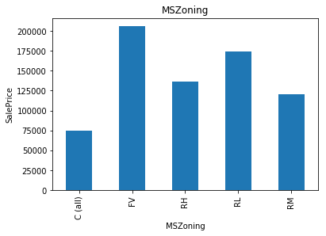

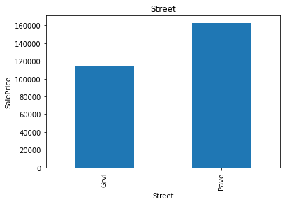

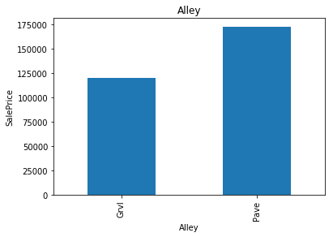

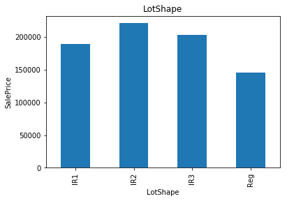

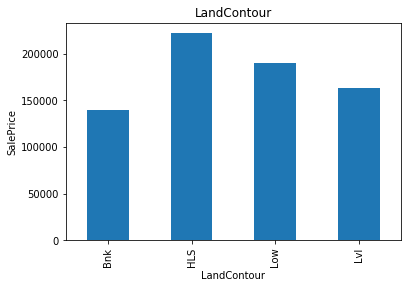

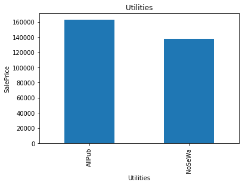

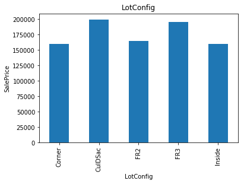

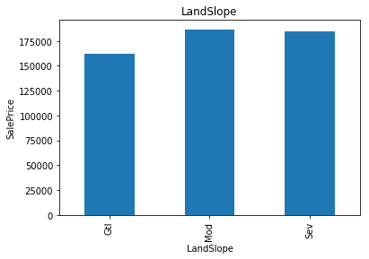

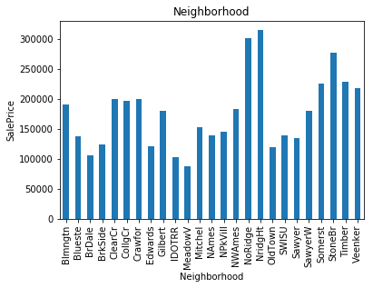

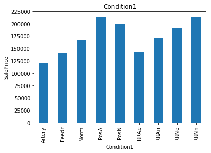

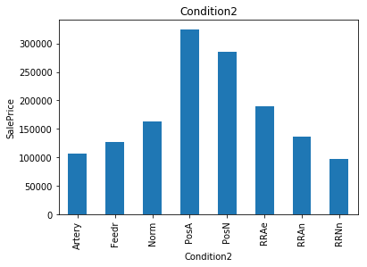

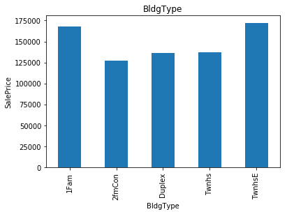

[31 more figures not shown]

```python
### Distribution of Categorical columns with SalePrice
for var in cat_vars:
    analyse_discrete(train_df, var)
```

```python
# to divide train and test set
from sklearn.model_selection import train_test_split

# feature scaling
from sklearn.preprocessing import MinMaxScaler
```

#### Split Data-set into Train and Test

```python
X_train, X_test, y_train, y_test = train_test_split(train_df, train_df["SalePrice"],
                                                    test_size=0.1,
                                                    random_state=0) # we are setting the seed here
print(X_train.shape, X_test.shape, y_train.shape, y_test.shape)
```

```
(1314, 81) (146, 81) (1314,) (146,)
```

## Feature Engineering

### Missing Values for Categorical Features

```python
# make a list of the categorical variables that contain missing values
vars_with_na = [var for var in train_df.columns if X_train[var].isnull().sum()>1 and X_train[var].dtypes=='O']

# print the variable name and the percentage of missing values
for var in vars_with_na:
    print(var, np.round(X_train[var].isnull().mean(), 3),'% missing values')
```

```
Alley 0.938 % missing values
MasVnrType 0.005 % missing values
BsmtQual 0.024 % missing values
BsmtCond 0.024 % missing values
BsmtExposure 0.025 % missing values
BsmtFinType1 0.024 % missing values
BsmtFinType2 0.025 % missing values
FireplaceQu 0.473 % missing values
GarageType 0.056 % missing values
GarageFinish 0.056 % missing values
GarageQual 0.056 % missing values
GarageCond 0.056 % missing values
PoolQC 0.995 % missing values
Fence 0.814 % missing values
MiscFeature 0.961 % missing values
```

```python
# function to replace NA with Missing in categorical variables
def fill_categorical_na(df, var_list):
    X = df.copy()
    X[var_list] = df[var_list].fillna('Missing')
    return X
```

```python
# replace missing values with new label: "Missing"
X_train = fill_categorical_na(X_train, vars_with_na)
X_test = fill_categorical_na(X_test, vars_with_na)

# check that we have no missing information in the engineered variables
X_train[vars_with_na].isnull().sum()
```

```
Alley           0
MasVnrType      0
BsmtQual        0
BsmtCond        0
BsmtExposure    0
BsmtFinType1    0
BsmtFinType2    0
FireplaceQu     0
GarageType      0
GarageFinish    0
GarageQual      0
GarageCond      0
PoolQC          0
Fence           0
MiscFeature     0
dtype: int64
```

```python
# check that test set does not contain null values in the engineered variables
[var for var in vars_with_na if X_test[var].isnull().sum()>0]
```

```
[]
```

### Missing Values for numerical features

```python
# make a list of the numerical variables that contain missing values
vars_with_na = [var for var in train_df.columns
                if X_train[var].isnull().sum()>1
                and X_train[var].dtypes!='O']

# print the variable name and the percentage of missing values
for var in vars_with_na:
    print(var, np.round(X_train[var].isnull().mean(), 3),  ' % missing values')
```

```
LotFrontage 0.177  % missing values
MasVnrArea 0.005  % missing values
GarageYrBlt 0.056  % missing values
```

```python
# replace the missing values
for var in vars_with_na:
    # calculate the mode
    mode_val = X_train[var].mode()[0]

    # train
    X_train[var].fillna(mode_val, inplace=True)

    # test
    X_test[var].fillna(mode_val, inplace=True)


# check that we have no more missing values in the engineered variables
X_train[vars_with_na].isnull().sum()
```

```
LotFrontage    0
MasVnrArea     0
GarageYrBlt    0
dtype: int64
```

```python
# check that test set does not contain null values in the engineered variables
[var for var in vars_with_na if X_test[var].isnull().sum()>0]
```

```
[]
```

### Temporal Variables

```python
def elapsed_years(df, var):
    # capture difference between year variable and year the house was sold
    df[var] = df['YrSold'] - df[var]
    return df
```

```python
for var in ['YearBuilt', 'YearRemodAdd', 'GarageYrBlt']:
    X_train = elapsed_years(X_train, var)
    X_test = elapsed_years(X_test, var)
```

```python
# check that test set does not contain null values in the engineered variables
[var for var in ['YearBuilt', 'YearRemodAdd', 'GarageYrBlt'] if X_test[var].isnull().sum()>0]
```

```
[]
```

### Numerical variables

We will log transform the numerical variables that do not contain zeros in order to get a more Gaussian-like distribution. This tends to help Linear machine learning models.

```python
for var in ['LotFrontage', 'LotArea', '1stFlrSF', 'GrLivArea', 'SalePrice']:
    X_train[var] = np.log(X_train[var])
    X_test[var]= np.log(X_test[var])
```

```python
# check that test set does not contain null values in the engineered variables
[var for var in ['LotFrontage', 'LotArea', '1stFlrSF', 'GrLivArea', 'SalePrice']
 if X_test[var].isnull().sum()>0]
```

```
[]
```

```python
# check for train set that does not contain null values in the engineered varaiables
[var for var in ['LotFrontage', 'LotArea', '1stFlrSF', 'GrLivArea', 'SalePrice']
 if X_train[var].isnull().sum()>0]
```

```
[]
```

### Categorical variables

We will remove those categories within variables that are present in less than 1% of the observations.

```python
cat_vars = [var for var in X_train.columns if X_train[var].dtype == 'O']
```

```python
def find_frequent_labels(df, var, rare_perc):
    # finds the labels that are shared by more than a certain % of the houses in the dataset
    df = df.copy()
    tmp = df.groupby(var)['SalePrice'].count() / len(df)
    return tmp[tmp>rare_perc].index

for var in cat_vars:
    frequent_ls = find_frequent_labels(X_train, var, 0.01)
    X_train[var] = np.where(X_train[var].isin(frequent_ls), X_train[var], 'Rare')
    X_test[var] = np.where(X_test[var].isin(frequent_ls), X_test[var], 'Rare')
```

We need to transform the strings of these variables into numbers or we can use LableEncoders

```python
def replace_categories(train, test, var, target):
    ordered_labels = train.groupby([var])[target].mean().sort_values().index
    ordinal_label = {k:i for i, k in enumerate(ordered_labels, 0)}
    train[var] = train[var].map(ordinal_label)
    test[var] = test[var].map(ordinal_label)
```

```python
for var in cat_vars:
    replace_categories(X_train, X_test, var, 'SalePrice')
```

```python
# check absence of na in X_train
[var for var in X_train.columns if X_train[var].isnull().sum()>0]
```

```
[]
```

```python
# check absence of na in X_test
[var for var in X_test.columns if X_test[var].isnull().sum()>0]
```

```
[]
```

### Feature Scaling or Normalization

```python
train_vars = [var for var in X_train.columns if var not in ['Id', 'SalePrice']]
len(train_vars)
```

```
79
```

```python
#X_train[['Id', 'SalePrice']].reset_index(drop=True)
```

```python
# fit scaler
scaler = MinMaxScaler() # create an instance
scaler.fit(X_train[train_vars]) #  fit  the scaler to the train set for later use

# transform the train and test set, and add on the Id and SalePrice variables
X_train = pd.concat([X_train[['Id', 'SalePrice']].reset_index(drop=True),
                    pd.DataFrame(scaler.transform(X_train[train_vars]), columns=train_vars)],
                    axis=1)

X_test = pd.concat([X_test[['Id', 'SalePrice']].reset_index(drop=True),
                    pd.DataFrame(scaler.transform(X_test[train_vars]), columns=train_vars)],
                    axis=1)
```

```python
X_train.head()
```

|  | Id | SalePrice | MSSubClass | MSZoning | LotFrontage | LotArea | Street | Alley | LotShape | LandContour | Utilities | LotConfig | LandSlope | Neighborhood | Condition1 | Condition2 | BldgType | HouseStyle | OverallQual | OverallCond | YearBuilt | YearRemodAdd | RoofStyle | RoofMatl | Exterior1st | Exterior2nd | MasVnrType | MasVnrArea | ExterQual | … |
| --- | --- | --- | --- | --- | --- | --- | --- | --- | --- | --- | --- | --- | --- | --- | --- | --- | --- | --- | --- | --- | --- | --- | --- | --- | --- | --- | --- | --- | --- | --- |
| 0 | 931 | 12.211060 | 0.000000 | 0.75 | 0.461171 | 0.377048 | 1.0 | 1.0 | 0.333333 | 1.000000 | 1.0 | 0.0 | 0.0 | 0.863636 | 0.4 | 1.0 | 0.75 | 0.6 | 0.777778 | 0.50 | 0.014706 | 0.049180 | 0.0 | 0.0 | 1.0 | 1.0 | 0.000000 | 0.00000 | 0.666667 | … |
| 1 | 657 | 11.887931 | 0.000000 | 0.75 | 0.456066 | 0.399443 | 1.0 | 1.0 | 0.333333 | 0.333333 | 1.0 | 0.0 | 0.0 | 0.363636 | 0.4 | 1.0 | 0.75 | 0.6 | 0.444444 | 0.75 | 0.360294 | 0.049180 | 0.0 | 0.0 | 0.6 | 0.6 | 0.666667 | 0.03375 | 0.666667 | … |
| 2 | 46 | 12.675764 | 0.588235 | 0.75 | 0.394699 | 0.347082 | 1.0 | 1.0 | 0.000000 | 0.333333 | 1.0 | 0.0 | 0.0 | 0.954545 | 0.4 | 1.0 | 1.00 | 0.6 | 0.888889 | 0.50 | 0.036765 | 0.098361 | 1.0 | 0.0 | 0.3 | 0.2 | 0.666667 | 0.25750 | 1.000000 | … |
| 3 | 1349 | 12.278393 | 0.000000 | 0.75 | 0.388581 | 0.493677 | 1.0 | 1.0 | 0.666667 | 0.666667 | 1.0 | 0.0 | 0.0 | 0.454545 | 0.4 | 1.0 | 0.75 | 0.6 | 0.666667 | 0.50 | 0.066176 | 0.163934 | 0.0 | 0.0 | 1.0 | 1.0 | 0.000000 | 0.00000 | 0.666667 | … |
| 4 | 56 | 12.103486 | 0.000000 | 0.75 | 0.577658 | 0.402702 | 1.0 | 1.0 | 0.333333 | 0.333333 | 1.0 | 0.0 | 0.0 | 0.363636 | 0.4 | 1.0 | 0.75 | 0.6 | 0.555556 | 0.50 | 0.323529 | 0.737705 | 0.0 | 0.0 | 0.6 | 0.7 | 0.666667 | 0.17000 | 0.333333 | … |

## Feature Selection

Why do we need to select variables?

1. For production: Fewer variables mean smaller client input requirements (e.g. customers filling out a form on a website or mobile app), and hence less code for error handling. This reduces the chances of bugs.
2. For model performance: Fewer variables mean simpler, more interpretable, less over-fitted models

**We will select variables using the Lasso regression: Lasso has the property of setting the coefficient of non-informative variables to zero. This way we can identify those variables and remove them from our final models.**

**Other Ways:**

1. Learning Curve
2. PCA
3. LDA
4. statModels

```python
# Models
from sklearn.linear_model import Lasso
from sklearn.feature_selection import SelectFromModel
```

```python
X_train.drop(['Id', 'SalePrice'], axis=1, inplace=True)
X_test.drop(['Id', 'SalePrice'], axis=1, inplace=True)
```

```python
print(X_train.shape,X_test.shape,y_train.shape, y_test.shape)
```

```
(1314, 79) (146, 79) (1314,) (146,)
```

```python
# First, Specify Lasso Regression model, and select a suitable alpha (equivalent of penalty).
# The bigger the alpha, less features will be selected.

# Then use the selectFromModel object from sklearn, which
# will select the features which coefficients are non-zero

sel_ = SelectFromModel(Lasso(alpha=900, random_state=0))
sel_.fit(X_train, y_train)
```

```
SelectFromModel(estimator=Lasso(alpha=900, copy_X=True, fit_intercept=True, max_iter=1000,
   normalize=False, positive=False, precompute=False, random_state=0,
   selection='cyclic', tol=0.0001, warm_start=False),
        max_features=None, norm_order=1, prefit=False, threshold=None)
```

```python
sel_.get_support()
```

```
array([ True, False, False, False, False, False, False, False, False,
        True, False,  True, False, False, False, False,  True, False,
       False,  True,  True, False, False, False,  True,  True,  True,
       False, False,  True, False,  True, False, False, False, False,
       False, False, False, False, False, False,  True,  True, False,
        True,  True, False, False, False, False, False,  True,  True,
       False,  True,  True, False, False,  True,  True,  True, False,
       False, False, False, False, False, False, False, False, False,
       False, False, False, False, False, False, False])
```

```python
selected_feat = X_train.columns[(sel_.get_support())]

# let's print some stats
print('total features: {}'.format((X_train.shape[1])))
print('selected features: {}'.format(len(selected_feat)))
print('features with coefficients shrank to zero: {}'.format(
    np.sum(sel_.estimator_.coef_ == 0)))
```

```
total features: 79
selected features: 22
features with coefficients shrank to zero: 57
```

```python
# print the selected features
selected_feat
```

```
Index(['MSSubClass', 'LotConfig', 'Neighborhood', 'OverallQual',
       'YearRemodAdd', 'RoofStyle', 'MasVnrType', 'MasVnrArea', 'ExterQual',
       'BsmtQual', 'BsmtExposure', '1stFlrSF', '2ndFlrSF', 'GrLivArea',
       'BsmtFullBath', 'KitchenQual', 'TotRmsAbvGrd', 'Fireplaces',
       'FireplaceQu', 'GarageFinish', 'GarageCars', 'GarageArea'],
      dtype='object')
```

## Machine Learning Model Building

```python
# to evaluate the models
from sklearn.metrics import mean_squared_error
from math import sqrt
```

```python
# reduce the train and test set to the desired features

X_train = X_train[selected_feat]
X_test = X_test[selected_feat]
```

```python
# train the model
lin_model = Lasso(alpha=0.005, random_state=0) # remember to set the random_state / seed
lin_model.fit(X_train, y_train)
```

```
Lasso(alpha=0.005, copy_X=True, fit_intercept=True, max_iter=1000,
   normalize=False, positive=False, precompute=False, random_state=0,
   selection='cyclic', tol=0.0001, warm_start=False)
```

```python
# We will evaluate performance using the mean squared error and the
# root of the mean squared error

pred = lin_model.predict(X_train)
print('linear train mse: {}'.format(mean_squared_error(y_train, pred)))
print('linear train rmse: {}'.format(sqrt(mean_squared_error(y_train, pred))))
print()
pred = lin_model.predict(X_test)
print('linear test mse: {}'.format(mean_squared_error(y_test, pred)))
print('linear test rmse: {}'.format(sqrt(mean_squared_error(y_test, pred))))
print()
print('Average house price: ', y_train.median())
```

```
linear train mse: 1025826952.9894029
linear train rmse: 32028.53341927168

linear test mse: 1378504284.4114976
linear test rmse: 37128.21412903532

Average house price:  163000.0
```

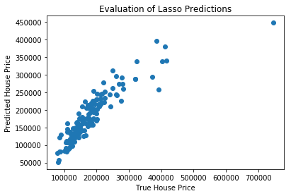

```python
# let's evaluate our predictions respect to the original price
plt.scatter(y_test, lin_model.predict(X_test))
plt.xlabel('True House Price')
plt.ylabel('Predicted House Price')
plt.title('Evaluation of Lasso Predictions')
```

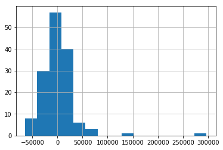

```python
# let's evaluate the distribution of the errors:
# they should be fairly normally distributed

errors = y_test - lin_model.predict(X_test)
errors.hist(bins=15)
```

### Feature Importance

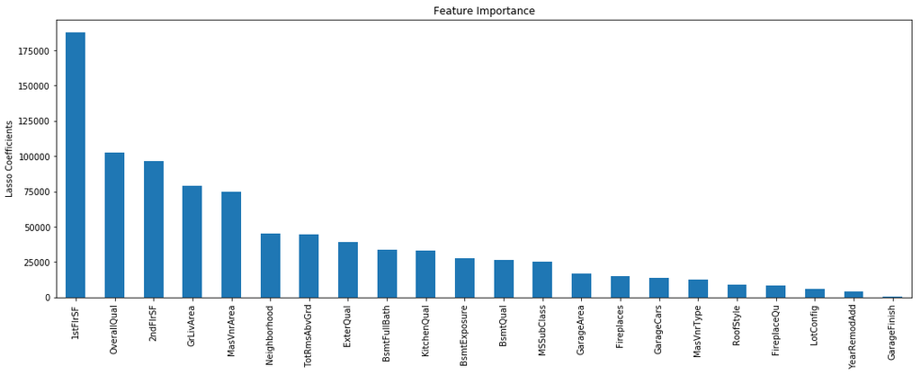

```python
importance = pd.Series(np.abs(lin_model.coef_.ravel()))
importance.index = selected_feat
importance.sort_values(inplace=True, ascending=False)
importance.plot.bar(figsize=(18,6))
plt.ylabel('Lasso Coefficients')
plt.title('Feature Importance')
```